# magicR

Maximilian Heeg

This vignette containes some examples on how to use the `magieR` wrapper to run `magic` on a `matrix`, a `SingleCellExperiment` and a `Seurat` object.

```r
library(magieR)
```

# Plain `magic` Example

Load the example dataset that is provided with the `magic-impute` package. (https://github.com/KrishnaswamyLab/MAGIC/blob/master/data/test_data.csv)

```r
m <- utils::read.csv(system.file("extdata", "test_data.csv", package = "magieR"))
m[1:10, 1:5]
```

```
#>    A1BG.AS1 AAMDC AAMP AARSD1 ABCA12
#> 1         0     0    0      0      0
#> 2         0     1    0      0      0
#> 3         1     0    1      0      0
#> 4         0     0    0      0      0
#> 5         0     0    0      0      0
#> 6         0     0    0      0      0
#> 7         0     0    0      0      0
#> 8         0     0    0      0      1
#> 9         0     0    0      0      0
#> 10        0     0    0      0      0
```

Then run `magic` on this matrix. It’s just as easy as that. You don’t have to worry about any python settings and configurations.

```r
result <- magieR(m)
# as.data.frame makes the output look a little nicer
as.data.frame(result)[1:10, 1:5]
```

```
#>       A1BG.AS1      AAMDC      AAMP      AARSD1     ABCA12
#> 1  0.012936400 0.07880955 0.1832819 0.027172252 0.04096136
#> 2  0.016952050 0.10841561 0.1432491 0.013564118 0.02935114
#> 3  0.040268001 0.06566941 0.2752440 0.011702112 0.02219317
#> 4  0.021806790 0.06535363 0.1546622 0.016562205 0.03884183
#> 5  0.026180051 0.04660360 0.1512381 0.010988680 0.02618466
#> 6  0.018759653 0.06934449 0.1761472 0.009922407 0.02294333
#> 7  0.009373936 0.04039007 0.1415848 0.005530573 0.02619369
#> 8  0.025859330 0.07173368 0.1906466 0.011596435 0.07468675
#> 9  0.021427551 0.06113871 0.1533276 0.017734990 0.02934404
#> 10 0.016651357 0.04892527 0.1656257 0.011193237 0.01945794
```

# Use `magic` on SingleCellExperiment

You can also use `magic` on a `SingleCellExperiment`. Let’s load the exemplary data from the [`scater` vignette](https://bioconductor.org/packages/release/bioc/vignettes/scater/inst/doc/overview.html).

```r
suppressPackageStartupMessages({
  library(scRNAseq)
  library(scater)
  library(SingleCellExperiment)
})

example_sce <- ZeiselBrainData()
```

[output not shown]

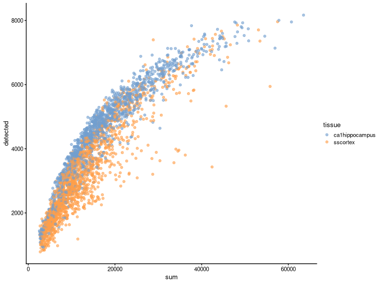

```r
example_sce <- addPerCellQC(example_sce,
    subsets=list(Mito=grep("mt-", rownames(example_sce))))

plotColData(example_sce, x = "sum", y="detected", colour_by="tissue")
```

```r
example_sce <- logNormCounts(example_sce)

vars <- getVarianceExplained(example_sce,
    variables=c("tissue", "total mRNA mol", "sex", "age"))
head(vars)
```

```
#>              tissue total mRNA mol         sex        age
#> Tspan12  0.02207262    0.074086504 0.146344996 0.09472155
#> Tshz1    3.36083014    0.003846487 0.001079356 0.31262288
#> Fnbp1l   0.43597185    0.421086301 0.003071630 0.64964174
#> Adamts15 0.54233888    0.005348505 0.030821621 0.01393787
#> Cldn12   0.03506751    0.309128294 0.008341408 0.02363737
#> Rxfp1    0.18559637    0.016290703 0.055646799 0.02128006
```

```r
example_sce <- runPCA(example_sce)

set.seed(1000)
example_sce <- runTSNE(example_sce, perplexity=50,
    dimred="PCA", n_dimred=10)
example_sce
```

```
#> class: SingleCellExperiment
#> dim: 20006 3005
#> metadata(0):
#> assays(2): counts logcounts
#> rownames(20006): Tspan12 Tshz1 ... mt-Rnr1 mt-Nd4l
#> rowData names(1): featureType
#> colnames(3005): 1772071015_C02 1772071017_G12 ... 1772066098_A12
#>   1772058148_F03
#> colData names(23): tissue group # ... total sizeFactor
#> reducedDimNames(2): PCA TSNE
#> altExpNames(2): ERCC repeat
```

Now we can run `magieR`. It uses the `logcounts` by default. Other assays can be used with `assay=`. The function returns a `sce`-object with a new alternative Expression. Alternative Expressions are used because if you run `magic` on a subset of genes with `genes=` the resulting dimensions of the matrix do not match the dimensions of the `sce`-object and therefore cannot be stored in `assays`.

```r
# run magieR
example_sce <- magieR(example_sce)
example_sce
```

```
#> class: SingleCellExperiment
#> dim: 20006 3005
#> metadata(0):
#> assays(2): counts logcounts
#> rownames(20006): Tspan12 Tshz1 ... mt-Rnr1 mt-Nd4l
#> rowData names(1): featureType
#> colnames(3005): 1772071015_C02 1772071017_G12 ... 1772066098_A12
#>   1772058148_F03
#> colData names(23): tissue group # ... total sizeFactor
#> reducedDimNames(2): PCA TSNE
#> altExpNames(3): ERCC repeat magic
```

```r
# the magic data can be accessed with
altExp(example_sce, "magic")
```

```
#> class: SingleCellExperiment
#> dim: 20006 3005
#> metadata(0):
#> assays(1): logcounts
#> rownames(20006): Tspan12 Tshz1 ... mt-Rnr1 mt-Nd4l
#> rowData names(0):
#> colnames(3005): 1772071015_C02 1772071017_G12 ... 1772066098_A12
#>   1772058148_F03
#> colData names(0):
#> reducedDimNames(0):
#> altExpNames(0):
```

Let’s display some genes with and without magic

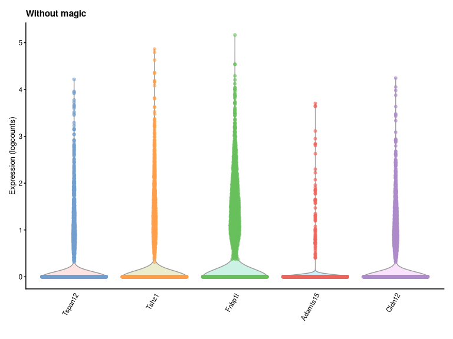

```r
plotExpression(example_sce, rownames(vars)[1:5]) +
  ggplot2::ggtitle("Without magic")
```

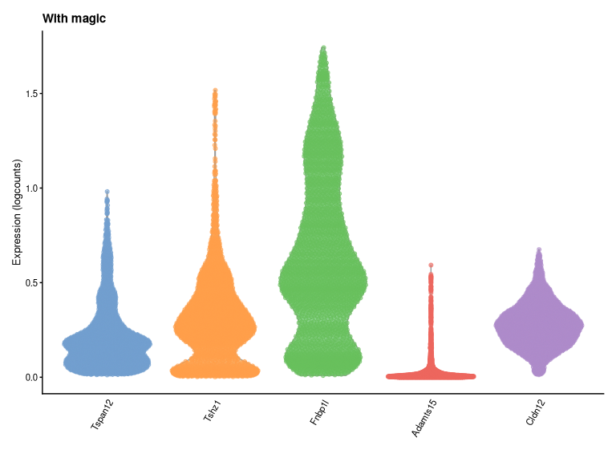

```r
plotExpression(altExp(example_sce, "magic"), rownames(vars)[1:5]) +
  ggplot2::ggtitle("With magic")
```

Or on a TSNE

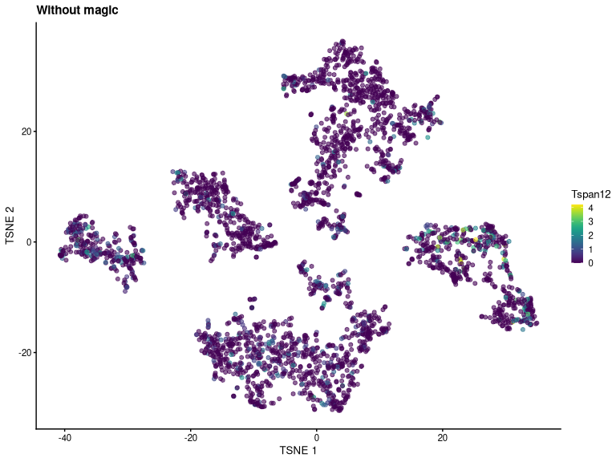

```r
plotTSNE(example_sce, colour_by="Tspan12") +
  ggplot2::ggtitle("Without magic")
```

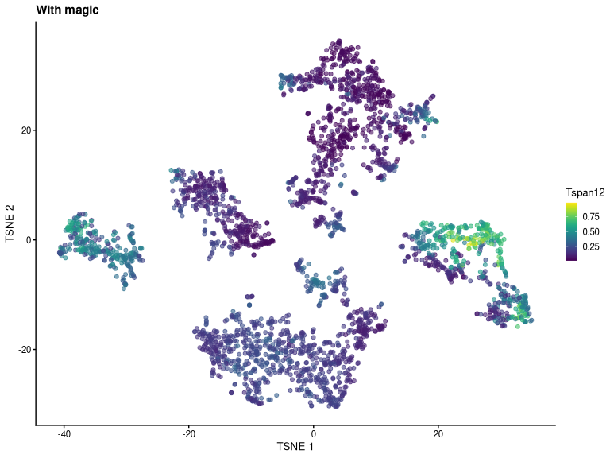

```r
# not sure if there is a more elegant way
# copy reduced dim to alt exp
reducedDim(altExp(example_sce, "magic"), "TSNE") <- reducedDim(example_sce, "TSNE")
plotTSNE(altExp(example_sce, "magic"), colour_by="Tspan12") +
  ggplot2::ggtitle("With magic")
```

# Use `magic` on a `Seurat` object

First we follow the standard Seurat workflow as described [here](https://satijalab.org/seurat/v3.2/pbmc3k_tutorial.html).

```r
suppressPackageStartupMessages({
  library(BiocFileCache)
  library(Seurat)
})

url = "https://cf.10xgenomics.com/samples/cell/pbmc3k/pbmc3k_filtered_gene_bc_matrices.tar.gz"

bfc <- BiocFileCache()
data <- bfcrpath(bfc, url)

tempdir <- file.path(tempdir(), "10_pbmc")
untar(data, exdir = tempdir)

pbmc.data <- Read10X(data.dir = file.path(tempdir, "filtered_gene_bc_matrices/hg19/"))

pbmc <- CreateSeuratObject(counts = pbmc.data, project = "pbmc3k", min.cells = 3, min.features = 200)
pbmc[["percent.mt"]] <- PercentageFeatureSet(pbmc, pattern = "^MT-")
pbmc <- subset(pbmc, subset = nFeature_RNA > 200 & nFeature_RNA < 2500 & percent.mt < 5)

pbmc <- NormalizeData(pbmc)

pbmc <- FindVariableFeatures(pbmc, selection.method = "vst", nfeatures = 2000)

top10 <- head(VariableFeatures(pbmc), 10)

all.genes <- rownames(pbmc)
pbmc <- ScaleData(pbmc, features = all.genes)
pbmc <- RunPCA(pbmc, features = VariableFeatures(object = pbmc))
```

[output not shown]

```r
pbmc <- RunUMAP(pbmc, dims = 1:10)
pbmc
```

```
#> An object of class Seurat
#> 13714 features across 2638 samples within 1 assay
#> Active assay: RNA (13714 features, 2000 variable features)
#>  2 dimensional reductions calculated: pca, umap
```

Okay, let’s run `magic`

```r
pbmc <- magieR(pbmc, slot="data")
pbmc
```

```
#> An object of class Seurat
#> 27428 features across 2638 samples within 2 assays
#> Active assay: RNA (13714 features, 2000 variable features)
#>  1 other assay present: magic
#>  2 dimensional reductions calculated: pca, umap
```

Again, make some plots.

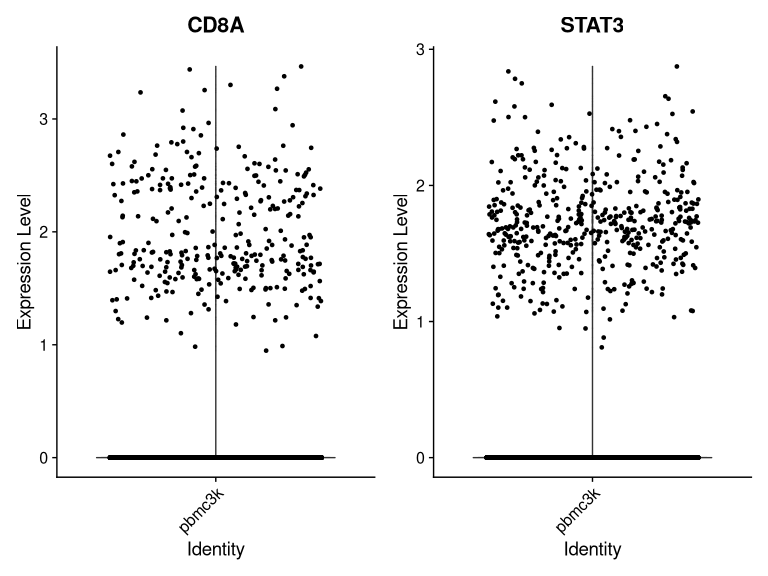

```r
VlnPlot(pbmc,
        features = c("CD8A", "STAT3"),
        same.y.lims = FALSE)
```

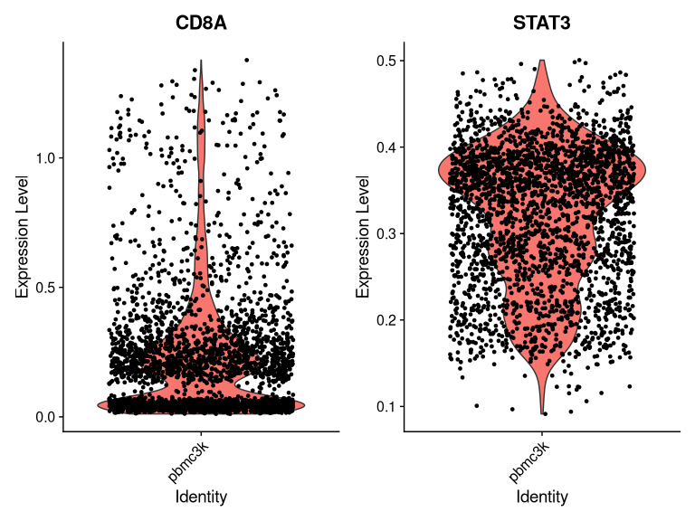

```r
VlnPlot(pbmc,
        features = c("CD8A", "STAT3"),
        same.y.lims = FALSE,
        assay="magic")
```

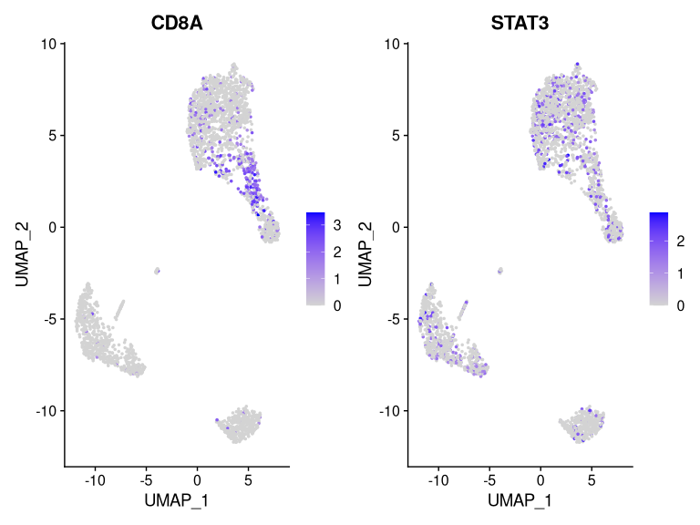

```r
FeaturePlot(pbmc, features = c("CD8A", "STAT3"))
```

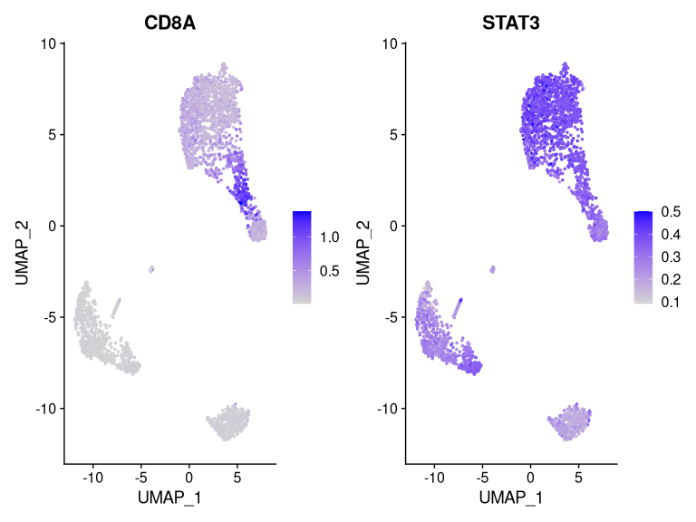

```r
# set the default assay to magic
Seurat::DefaultAssay(pbmc) <- "magic"
FeaturePlot(pbmc, features = c("CD8A", "STAT3"))
```

```r
# set if back to default ("RNA"). You only want to use magic for visualization
# and never for statistics.
Seurat::DefaultAssay(pbmc) <- "RNA"
```